# Diet protein study: ESM-2 8M as a ground metric

`docs/ground_metric_models.md` picked TM-Vec1 as the package’s one ground metric because its head regresses TM-score, so cosine similarity is a named, calibrated quantity. ESM-2 was dropped from `embed_proteins()` for the opposite reason: its geometry is a side effect of a masked-language objective, uncalibrated at any size, and the survey’s own measurement at 8M parameters – the exact checkpoint used below – found long-range contact P@L 0.17 (against 0.52 at 650M), same-superfamily AUROC 0.766 against a length-alone baseline of 0.722, and length plus amino-acid composition already explaining 0.445 of the embedding’s own variance. “Structure” is not a defensible label for what this model encodes.

That is a reason not to trust *what the distance means*, not a reason it can’t detect anything. This report plugs `weightedRep()` into the same beta-diversity pipeline as `case_study.Rmd` with ESM-2 8M in the ground-metric slot, purely to show the method runs against a different embedding backend – it is not a candidate to replace TM-Vec1, and nothing here tries to explain what a resulting distance is picking up on (structure, homology, taxonomy, composition, length – all plausible, none adjudicated here). Nothing past beta diversity (differential abundance, structural rollup) is repeated either.

```r
Sys.setenv(KMP_DUPLICATE_LIB_OK = "TRUE")

library(phyloseq)
library(vegan)
library(ggplot2)
library(gt)
library(here)
for (f in list.files("R", full.names = TRUE)) source(f)

path  <- here("data", "test_study")
NPERM <- 9999
```

## Data and rarefaction

Same table, same rarefaction as `case_study.Rmd`, reproduced here rather than sourced so this report renders standalone: rarefy to the shallowest sample, drop the baseline phase (diet is undefined there).

```r
ps <- readRDS(file.path(path, "ps.rds"))
floor_depth <- min(sample_sums(ps))

# rarefy_even_depth() reads .Random.seed before it sets one; in a fresh Rscript
# session (no prior RNG use) that variable doesn't exist yet and it errors.
set.seed(1)

psd <- rarefy_even_depth(ps, sample.size = floor_depth, rngseed = 1,
                         replace = FALSE, verbose = FALSE)
psd <- prune_samples(sample_data(psd)$phase != "baseline", psd)
psd <- prune_taxa(taxa_sums(psd) > 0, psd)
sample_data(psd)$diet <- factor(sample_data(psd)$diet)
sample_data(psd)$dose <- factor(sample_data(psd)$dose)
psd
```

```
## phyloseq-class experiment-level object
## otu_table()   OTU Table:         [ 19192 taxa and 99 samples ]
## sample_data() Sample Data:       [ 99 samples by 9 sample variables ]
## tax_table()   Taxonomy Table:    [ 19192 taxa by 8 taxonomic ranks ]
## refseq()      AAStringSet:      [ 19192 reference sequences ]
```

## Embedding

`facebook/esm2_t6_8M_UR50D` via plain `transformers` – unlike ESM C, ESM-2 has been a registered `AutoModel` architecture for years, so this needs nothing beyond the `torch`/`transformers` dependency `embed_proteins()` already carries for TM-Vec1, no separate SDK. Same pooling convention as the rest of this analysis family: the tokenizer wraps every sequence in `<cls> ... <eos>`, and the pooled vector averages only the residue positions, not the two flanking special tokens or right-padding, over the frozen encoder (no trained head). `max_position_embeddings` is 1026 (1024 residues plus the two special tokens); 1017 of 19192 proteins here exceed that and are truncated.

```r
# cache = FALSE: same reasoning as case_study.Rmd's embed chunk -- the rds file,
# keyed by protein id, is the only cache that actually tracks what's embedded.
ESM2_PY <- r"(
import torch
from transformers import AutoModel, AutoTokenizer

_ESM2_CACHE = {}

def _repbeta_esm2_model(repo, device):
    if repo not in _ESM2_CACHE:
        tok = AutoTokenizer.from_pretrained(repo)
        model = AutoModel.from_pretrained(repo).eval().to(device)
        _ESM2_CACHE[repo] = (tok, model)
    return _ESM2_CACHE[repo]

def _repbeta_esm2(seqs, repo, device):
    tok, model = _repbeta_esm2_model(repo, device)
    enc = tok(seqs, return_tensors="pt", padding=True)
    enc = {k: v.to(device) for k, v in enc.items()}
    with torch.no_grad():
        h = model(**enc).last_hidden_state
    lens = enc["attention_mask"].sum(1)
    mask = enc["attention_mask"].clone()
    for i, n in enumerate(lens.tolist()):
        mask[i, 0] = 0         # <cls>
        mask[i, n - 1] = 0     # <eos>
    mask = mask.unsqueeze(-1).float()
    pooled = (h * mask).sum(1) / mask.sum(1)
    return pooled.cpu().numpy()
)"

embed_esm2 <- function(seqs, model = "facebook/esm2_t6_8M_UR50D",
                       device = c("mps", "cuda", "cpu"), batch_size = 16) {
  device <- match.arg(device)
  reticulate::py_require(c("torch", "transformers"))
  torch <- reticulate::import("torch")
  reticulate::py_run_string(ESM2_PY)
  torch$set_grad_enabled(FALSE)
  on.exit(torch$set_grad_enabled(TRUE), add = TRUE)

  prepped <- substr(toupper(seqs), 1, 1024)   # 1026-token context minus <cls>/<eos>
  lens <- nchar(prepped)
  out <- NULL

  # same token-budget batching as embed_proteins() in R/embed.R, reusing its TOKEN_BUDGET
  chunks <- list(); i <- 1L
  while (i <= length(prepped)) {
    j <- i
    while (j < length(prepped) && (j - i + 2L) * max(lens[i:(j + 1L)]) <= TOKEN_BUDGET &&
           (j - i + 2L) <= batch_size) j <- j + 1L
    chunks[[length(chunks) + 1L]] <- i:j
    i <- j + 1L
  }

  for (idx in chunks) {
    arr <- reticulate::py_to_r(reticulate::py$`_repbeta_esm2`(
      as.list(unname(prepped[idx])), model, device))
    if (is.null(out)) out <- matrix(NA_real_, nrow = length(prepped), ncol = ncol(arr))
    out[idx, ] <- arr
    if (device == "mps") torch$mps$empty_cache() else if (device == "cuda") torch$cuda$empty_cache()
  }
  rownames(out) <- names(seqs)
  out
}

cache <- file.path(path, "embeddings_esm2_8M.rds")
Zall  <- if (file.exists(cache)) readRDS(cache) else NULL
need  <- setdiff(taxa_names(psd), rownames(Zall))

if (length(need)) {
  s <- as.character(refseq(psd)[need])
  s <- s[order(nchar(s))]                      # length-sorted: keeps batches tight
  for (i in split(seq_along(s), ceiling(seq_along(s) / 2000))) {
    Zall <- rbind(Zall, embed_esm2(s[i], batch_size = 16))
    saveRDS(Zall, cache)
  }
}
Z <- Zall[taxa_names(psd), ]
```

## Results

Bray-Curtis and Jaccard as the protein-identity baselines, `weightedRep` on the ESM-2 8M embedding as the test. Same PERMANOVA specification as `case_study.Rmd`: amount of protein, sex and age as covariates, only the diet term reported, permutations blocked within mouse.

```r
cnt <- t(as(otu_table(psd), "matrix"))     # samples in rows
md  <- data.frame(sample_data(psd))
D <- list(`Bray-Curtis` = phyloseq::distance(psd, method = "bray"),
          `Jaccard`     = vegdist(cnt, method = "jaccard", binary = TRUE),
          `weightedRep (ESM-2 8M)` = weightedRep(cnt, Z, method = "mmd"))

diet_test <- function(dl) do.call(rbind, lapply(names(dl), function(n) {
  set.seed(1)
  a <- adonis2(dl[[n]] ~ diet + dose + sex + age_week, data = md, by = "terms",
               permutations = permute::how(blocks = factor(md$subject), nperm = NPERM))
  data.frame(distance = n, R2 = round(a["diet", "R2"], 3),
             F = round(a["diet", "F"], 2), p = a["diet", "Pr(>F)"])
}))
res <- diet_test(D)
r2  <- setNames(res$R2, res$distance)
gt(res)
```

| distance | R2 | F | p |
| --- | --- | --- | --- |
| Bray-Curtis | 0.281 | 9.60 | 1e-04 |
| Jaccard | 0.192 | 5.12 | 1e-04 |
| weightedRep (ESM-2 8M) | 0.430 | 17.38 | 1e-04 |

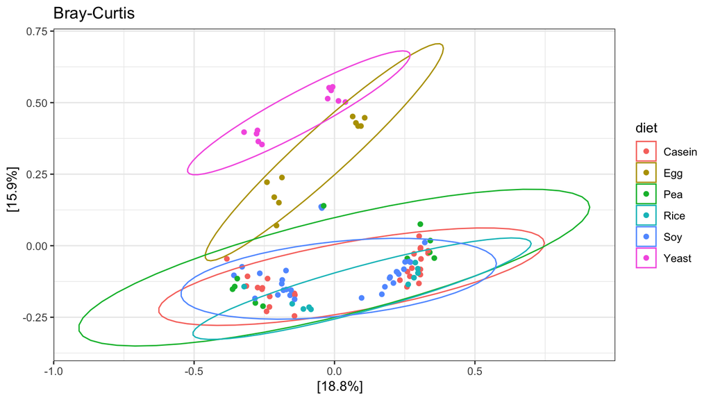

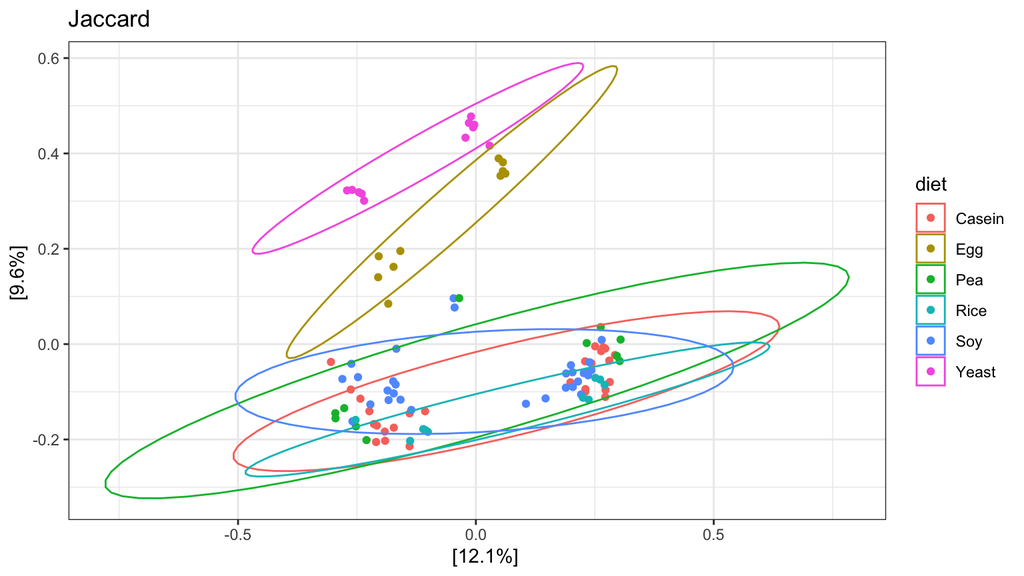

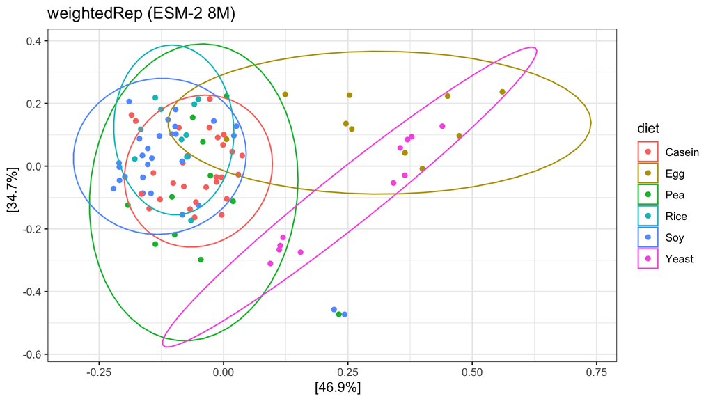

```r
for (n in names(D)) {
  print(plot_ordination(psd, ordinate(psd, "PCoA", distance = D[[n]]), color = "diet") +
          stat_ellipse(type = "t", geom = "polygon", alpha = 0) +
          ggtitle(n) + theme_bw())
}
```

```r
gt(data.frame(
  distance     = names(D),
  betadisper_p = sapply(D, function(d) round(anova(betadisper(d, md$diet))$`Pr(>F)`[1], 4)),
  row.names = NULL))
```

| distance | betadisper_p |
| --- | --- |
| Bray-Curtis | 0.000 |
| Jaccard | 0.000 |
| weightedRep (ESM-2 8M) | 0.295 |

## Conclusion

`case_study.Rmd` reported diet $R^2$ of 0.281 (Bray-Curtis), 0.192 (Jaccard) and 0.335 (TM-Vec1 `weightedRep`). Here, ESM-2 8M’s `weightedRep` lands at $R^2=$ 0.430 (Bray-Curtis and Jaccard reproduce at 0.281 and 0.192, as expected since nothing about the counts or the rarefaction changed).

That number alone does not settle whether ESM-2 8M’s geometry is doing anything a random projection wouldn’t – `docs/ground_metric_models.md` §6 measured a random 320-d embedding at diet $R^2=0.29$ on this same table (chosen to match this model’s own hidden size), so a value in that neighborhood is the null, not a finding, and clearing it needs the Mantel-against-random-projection check that document describes, not run here. What this report settles on its own is narrower: whether `weightedRep()` runs end to end and reads some diet signal with the exact 8M checkpoint the ground-metric survey used to reject the uncalibrated family, on real data rather than the survey’s fold-recognition benchmark. The comparison above is that number, nothing more – no claim about what the distance is picking up on, no dispersion argument, no accession-shuffle robustness check.